# Assignment 3

Your name here

Today’s date here: 10/25/2021

Collaborators: Carolina Herrera Figueroa

This assignment is due on Canvas on Wednesday 10/27/2021 before class, at 10:15 am. Include the name of anyone with whom you collaborated at the top of the assignment.

Submit your responses as either an HTML file or a PDF file on Canvas. Also, please upload it to your website.

Save the file (found on Canvas) crime_simple.txt to the same folder as this file (your Rmd file for Assignment 3).

Load the data.

```r
library(readr)
library(knitr)
dat.crime <- read_delim("crime_simple.txt", delim = "\t")
```

This is a dataset from a textbook by Brian S. Everitt about crime in the US in 1960. The data originate from the Uniform Crime Report of the FBI and other government sources. The data for 47 states of the USA are given.

Here is the codebook:

R: Crime rate: # of offenses reported to police per million population

Age: The number of males of age 14-24 per 1000 population

S: Indicator variable for Southern states (0 = No, 1 = Yes)

Ed: Mean of years of schooling x 10 for persons of age 25 or older

Ex0: 1960 per capita expenditure on police by state and local government

Ex1: 1959 per capita expenditure on police by state and local government

LF: Labor force participation rate per 1000 civilian urban males age 14-24

M: The number of males per 1000 females

N: State population size in hundred thousands

NW: The number of non-whites per 1000 population

U1: Unemployment rate of urban males per 1000 of age 14-24

U2: Unemployment rate of urban males per 1000 of age 35-39

W: Median value of transferable goods and assets or family income in tens of $

X: The number of families per 1000 earning below 1/2 the median income

We are interested in checking whether the reported crime rate (# of offenses reported to police per million population) and the average education (mean number of years of schooling for persons of age 25 or older) are related.

1. How many observations are there in the dataset? To what does each observation correspond?

```r
nrow(dat.crime)
```

```
## [1] 47
```

```r
ncol(dat.crime)
```

```
## [1] 14
```

```r
head(dat.crime)
```

```
## # A tibble: 6 × 14
##       R   Age     S    Ed   Ex0   Ex1    LF     M     N    NW    U1    U2     W
##   <dbl> <dbl> <dbl> <dbl> <dbl> <dbl> <dbl> <dbl> <dbl> <dbl> <dbl> <dbl> <dbl>
## 1  79.1   151     1    91    58    56   510   950    33   301   108    41   394
## 2 164.    143     0   113   103    95   583  1012    13   102    96    36   557
## 3  57.8   142     1    89    45    44   533   969    18   219    94    33   318
## 4 197.    136     0   121   149   141   577   994   157    80   102    39   673
## 5 123.    141     0   121   109   101   591   985    18    30    91    20   578
## 6  68.2   121     0   110   118   115   547   964    25    44    84    29   689
## # … with 1 more variable: X <dbl>
```

2. Draw a scatterplot of the two variables. Calculate the correlation between the two variables. Can you come up with an explanation for this relationship?

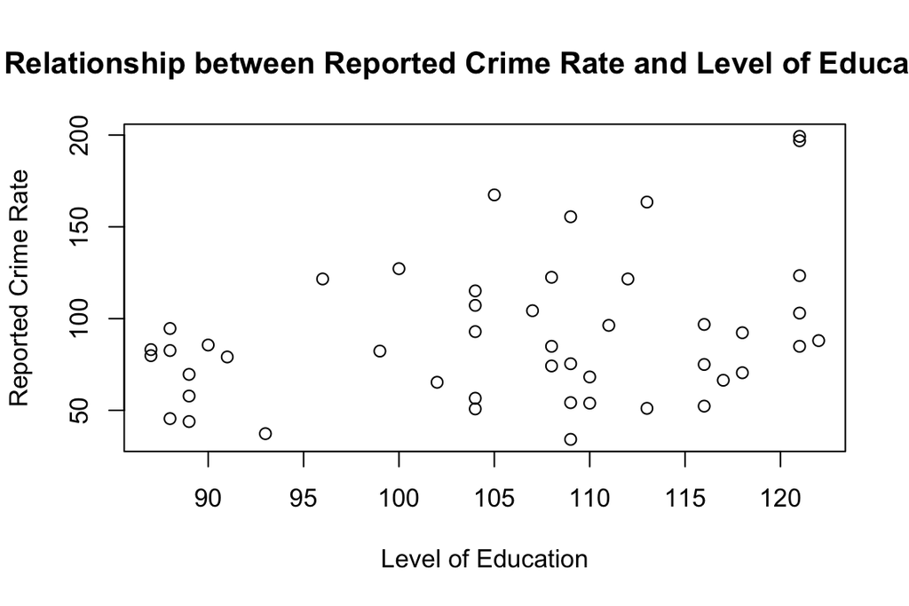

```r
library(datasets)
plot(dat.crime$Ed, dat.crime$R,  main="Relationship between Reported Crime Rate and Level of Education",
    xlab="Level of Education", ylab="Reported Crime Rate")
```

```r
cor(dat.crime$Ed, dat.crime$R)
```

```
## [1] 0.3228349
```

The correlation between the two variables is 0.3228. Given that correlations range from -1 to 1 this shows a rather small positive correlation. That is, there is a slightly positive relationship between the level of education and the number of reported crimes. It is reasonable that this number is relatively low though because this relationship is not a direct causation.

3. Regress reported crime rate (y) on average education (x) and call this linear model `crime.lm` and write the summary of the regression by using this code, which makes it look a little nicer `{r, eval=FALSE} kable(summary(crime.lm)$coef, digits = 2)`.

```r
reg.output <- lm(formula = R ~ Ed, data=dat.crime)
```

```r
summary(reg.output)
```

[output not shown]

4. Are the four assumptions of linear regression satisfied? To answer this, draw the relevant plots. (Write a maximum of one sentence per assumption.)

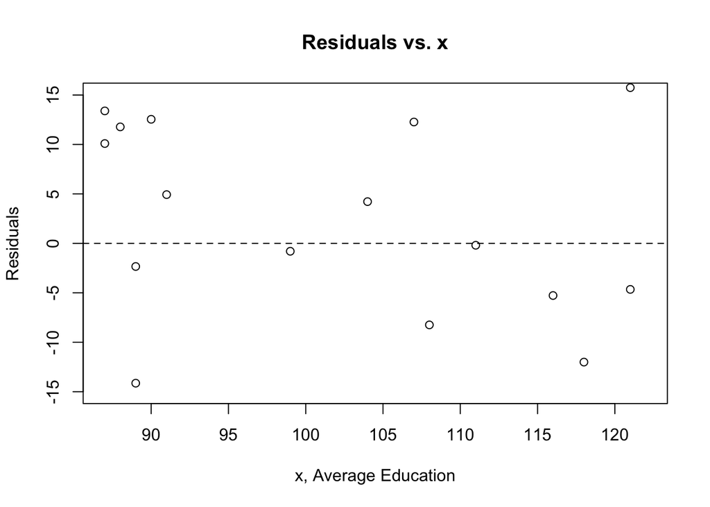

```r
plot(dat.crime$Ed, reg.output$residuals, ylim=c(-15,15), main="Residuals vs. x", xlab="x, Average Education", ylab="Residuals")
abline(h = 0, lty="dashed")
```

For residuals vs X, if the linearity assumption is satisfied there should be no pattern around the horizontal line, so it can be said that for this data set the linearity assumption holds true.

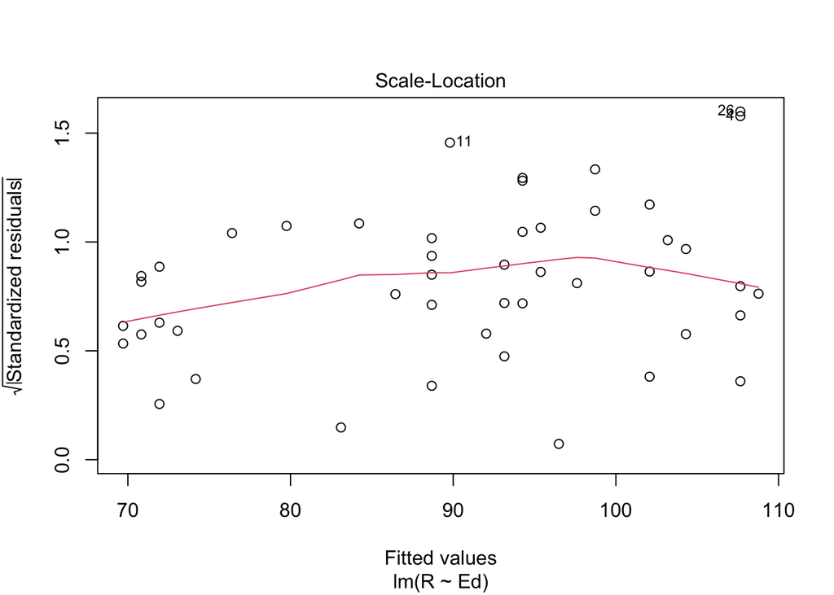

```r
plot(reg.output, which=3)
```

The third assumption, equal variance, holds true because there does not seem to be a trend in the red line: it appears mostly flat.

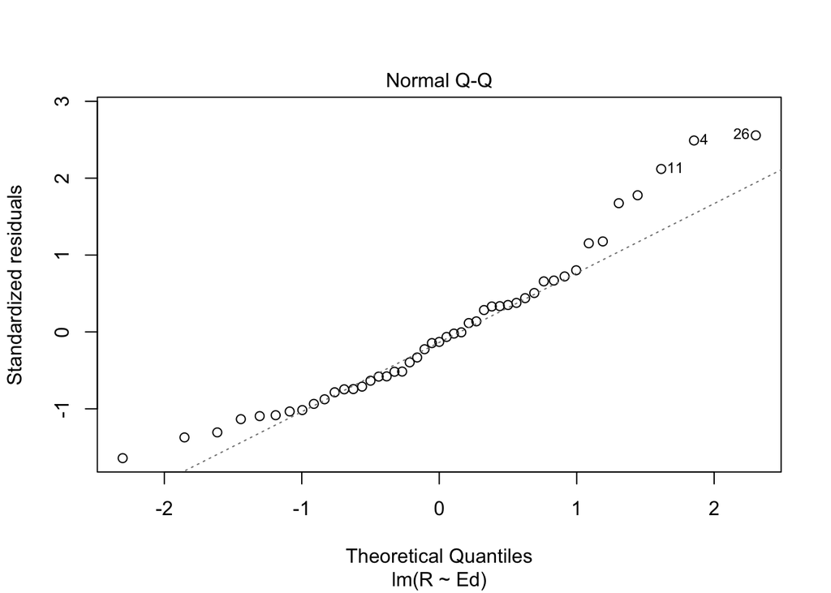

```r
plot(reg.output, which=2)
```

The normal QQ plot shows that the last assumption is not fully satisfied beucause while the points appear gathered on the line in the middle range, the values less than -1 and greater than 1 appear further from the line than ideal.

5. Is the relationship between reported crime and average education statistically significant? Report the estimated coefficient of the slope, the standard error, and the p-value. What does it mean for the relationship to be statistically significant?

6. How are reported crime and average education related? In other words, for every unit increase in average education, how does reported crime rate change (per million) per state?

Given the slope of 1.116, for every unit increase in education, reported crime rate increases by a factor of 1.116 reports per million per state.

7. Can you conclude that if individuals were to receive more education, then crime will be reported more often? Why or why not?

It cannot be concluded that if individuals were to reccieve more education then crime will be reported more often. Using this one data set does not mean that the results are generalizable.